BACK TO SCHEDULE

- Quantitative by Categorical
- The Side-by-Side Box Plot
- Numeric to Factor

# Quantitative by Categorical

### Numeric Summary of One Quantitative by A Categorical Variable

Consider the data frame **CO2**

> Open R Gui. In Console type: *library(Rcmdr)*

> Click on DATA > DATA IN PACKAGES > READ DATA FROM AN ATTACHED PACKAGE > Enter name of data set: **CO2**

> Click on “View data set” to display the data table. *(optional)*

Summarize the variable “carbon dioxide uptake rate”: **uptake**.

> STATISTICS > SUMMARIES > NUMERICAL SUMMARIES > Select variable: uptake > OK

```
   Min. 1st Qu.  Median    Mean 3rd Qu.    Max.
   7.70   17.90   28.30   27.21   37.12   45.50
```

Next, summarize the variable **uptake** by each category in **Treatment**.

> STATISTICS > SUMMARIES > NUMERICAL SUMMARIES > Select variable “uptake”

> SUMMARIZE BY GROUPS > Select the variable “Treatment” > OK > OK

```
$nonchilled
   Min. 1st Qu.  Median    Mean 3rd Qu.    Max.
  10.60   26.48   31.30   30.64   38.70   45.50

$chilled
   Min. 1st Qu.  Median    Mean 3rd Qu.    Max.
   7.70   14.53   19.70   23.78   34.90   42.40
```

This exercise show the steps to summarize any quantitative variable by groups of a categorical.

# The Side-by-Side Box plot

For a quantitative variable, the side-by-side boxplot compares the box plots for each level in a categorical.

For example, consider the side-by-side boxplot of carbon dioxide uptake rates by treatments.

> GRAPHS > BOXPLOTS > Select variable: uptake

> PLOT BY GROUPS > Select: Treatment > OK > OK

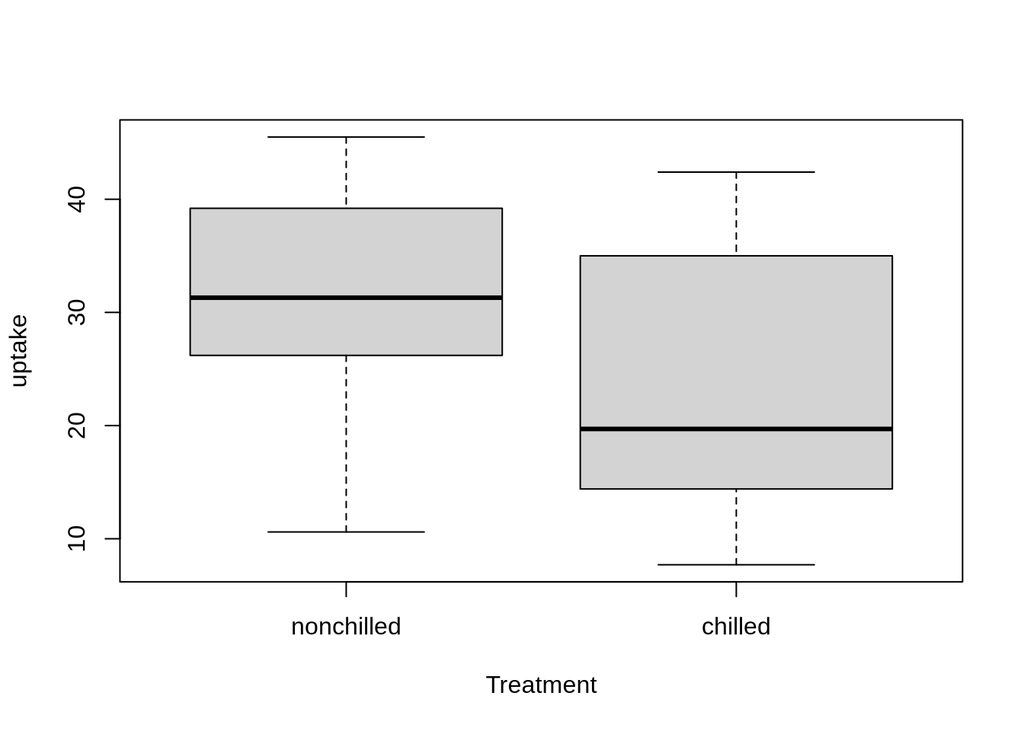

You can add axis labels and plot title in the OPTIONS tab before displaying the charts.

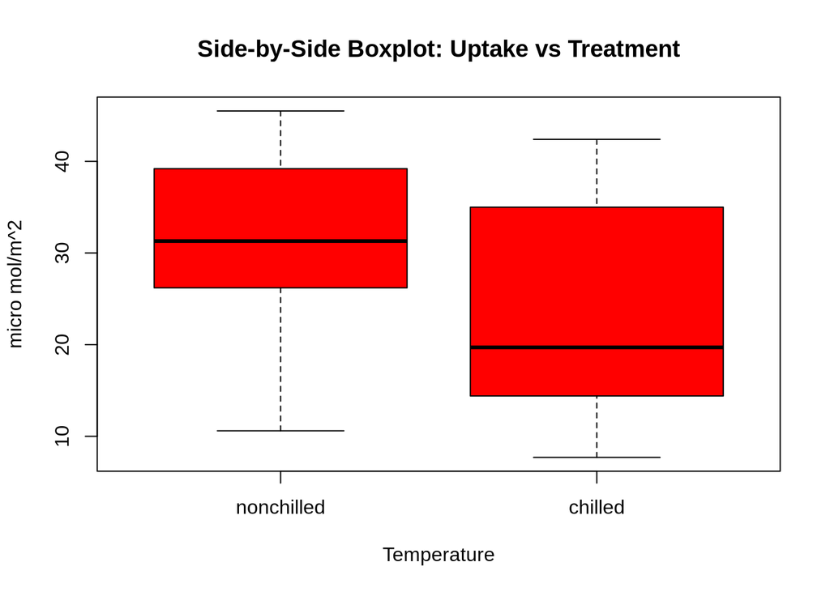

# Converting a Numeric to Factor

Sometimes categorical variables in data frames have numeric values without labels. For this reason, it is important to assign labels to these values for the correct analysis.

For example, consider the classification of cars according to number of cylinders in the data frame **mtcars**. We want to find out if fuel efficiency is affected by the number of cylinders.

The variable “number of cylinders”, cyl, does not have proper labels.

We fix this problem by making **cyl** a “factor” class in R.

> Open R GUI and open the **mtcars** variables following the steps described previously.

> Once *mtcars* is active, click on DATA > MANAGE VARIABLES IN ACTIVE DATA SET > CONVERT NUMERIC VARIABLES IN FACTORS

> Select the variable **cyl**. Define the New Variable: **cyl_2**. *(This name is optional)*.

> Insert the Label Names. For example, in 4, you may type “Four Cylinders”. Type “Six Cylinders” and “Eight Cylinders” for the others > OK

Once we create the categorical version of *cyl*, compute the summary and side-by-side boxplot.

```
$`Four cylinders`
   Min. 1st Qu.  Median    Mean 3rd Qu.    Max.
  21.40   22.80   26.00   26.66   30.40   33.90

$`Six cylinders`
   Min. 1st Qu.  Median    Mean 3rd Qu.    Max.
  17.80   18.65   19.70   19.74   21.00   21.40

$`Eight cylinders`
   Min. 1st Qu.  Median    Mean 3rd Qu.    Max.
  10.40   14.40   15.20   15.10   16.25   19.20
```

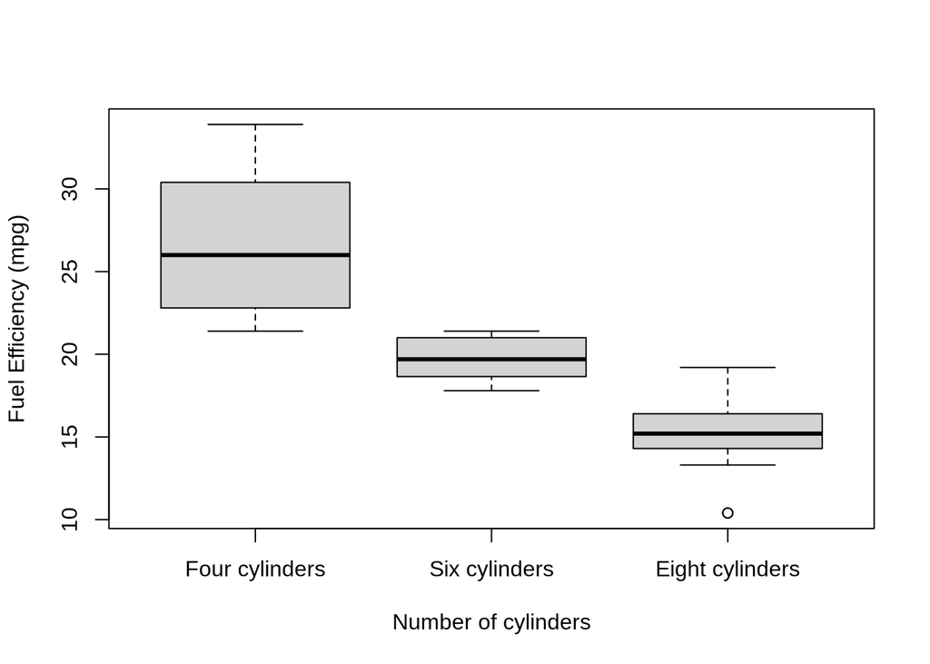

**Some Observations:**

- By comparing the median, the side-by-side box plots suggest that cars’ fuel efficiency decreases with larger number of cylinders.
- Four-cylinder cars have the largest mpg variation (IQR).
- There is one car with the poorest fuel efficiency. Even among the eight-cylinder cars, its performance is very unusual.